# NBA team seasons

15-03-2017

## Features of the web app

The web app consists of several features:

1. Graphical comparison of the total wins per season between two teams
2. Average win comparison of the total wins per season between two teams
3. Adjustable time scale (in years) for the two comparisons mentioned above
4. Ranking of all NBA teams by total wins in an adjustable time scale

## The data

The data used for this webapp contains data on all seasons of the National Basketball Association by team. There are many different statistics on each team, but for this webapp only the team, the year and the amount of wins were relevant.

```r
t_s <- read.csv("team_season.csv",sep=",")
colnames(t_s)[1] <- "team"
head(t_s[,c("team","year","won")])
```

```
##   team year won
## 1  BOS 1946  22
## 2  CH1 1946  39
## 3  CL1 1946  30
## 4  DE1 1946  20
## 5  NYK 1946  33
## 6  PH1 1946  35
```

```r
dim(t_s[,c("team","year","won")])
```

```
## [1] 1338    3
```

## Example of the plot

The following plot shows the wins of the Los Angeles Lakers (LAL) and Boston Celtics (BOS) between the years 1980 and 2000.

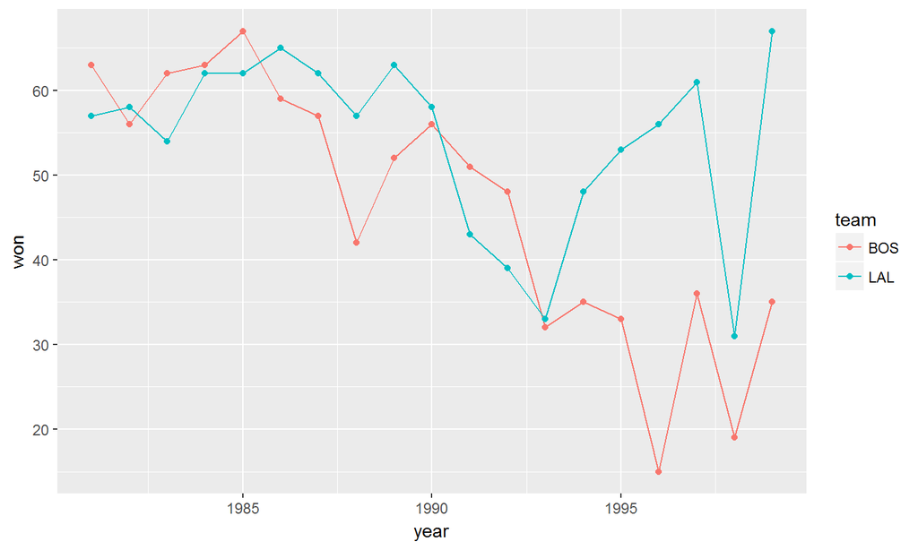